# Μελαγχολική(;) Μουσική

Εμπνευσμένο από το άρθρο του Economist [Data from Spotify suggest that listeners are gloomiest in February](https://www.economist.com/graphic-detail/2020/02/08/data-from-spotify-suggest-that-listeners-are-gloomiest-in-february).

> Πάνος Λουρίδας, Αναπληρωτής Καθηγητής  
> Τμήμα Διοικητικής Επιστήμης και Τεχνολογίας  
> Οικονομικό Πανεπιστήμιο Αθηνών  
> louridas@aueb.gr

# Προετοιμασία

- Για να χρησιμοποιήσετε το API του Spotify, θα πρέπει να κατευθυνθείτε στο http://developer.spotify.com και να δηλώσετε μια εφαρμογή που θα το χρησιμοποιεί.
- Θα πρέπει να μπείτε στην υπηρεσία (άρα πρέπει να έχετε λογαριασμό στο Spotify).
- Στη συνέχεια μπορείτε να πάτε στον πίνακα ελέγχου (dashboard) και να δημιουργήσετε την εφαρμογή σας.
- Θα χρειαστεί να δημιουργήσετε μία ταυτότητα πελάτη (client ID) και έναν μυστικό κωδικό πελάτη (client secret) με τα οποία η εφαρμογτή σας θα μπορεί να χρησιμοποιήσει το API του Spotify.
- Έχετε υπόψη ότι η χρήση του API του Spotify υπόκειται σε περιορισμούς ([rate limits](https://developer.spotify.com/documentation/web-api/guides/rate-limits/)).

```python
import pandas as pd
import numpy as np
import scipy.stats as stats
import statsmodels.api as sm
import statsmodels.formula.api as smf

import glob
import re
from datetime import datetime

import spotipy
from spotipy.oauth2 import SpotifyClientCredentials

import matplotlib.pyplot as plt
import seaborn as sns

%matplotlib inline
```

- Θέλουμε να διερευνήσουμε τα πιο δημοφιλή μουσικά κομμάτια στον κόσμο.
- Αυτά δίνονται από το [Spotify Charts](https://spotifycharts.com/).
- Δυστυχώς, παρά το ότι τα δεδομένα είναι διαθέσιμα σε μορφή CSV, μπορούμε να κατεβάσουμε δεδομένα μόνο για κάθε μία εβδομάδα ξεχωριστά.
- Ευτυχώς, δεδομένα για κάποιες χώρες και συνολικά για όλον τον κόσμο, για την περίοδο 2017-2019, είναι διαθέσιμα στο Zenodo https://doi.org/10.5281/zenodo.4778562:
  - Gabriel P. Oliveira, Mariana O. Silva, Danilo B. Seufitelli, Anisio Lacerda, and Mirella M. Moro. Detecting Collaboration Profiles in Success-based Music Genre Networks. In Proceedings of the 21st International Society for Music Information Retrieval Conference (ISMIR 2020), 2020.
- Από το Zenodo λοιπόν μπορούμε να κατεβάσουμε το αρχείο με τα δημοφιλή κομμάτια (`charts.zip`).
- Αν αποσυμπιέσουμε το αρχείο, θα δούμε ότι τοποθετεί τα αρχεία για κάθε περιοχή σε ξεχωριστό κατάλογο.
- Σε κάθε κατάλογο, τα δεδομένα είναι αποθηκευμένα σε εβδομαδιαία αρχεία.
- Θα τα διαβάσουμε όλα, καταγράφοντας την εβδομάδα και την περιοχή.

```python
header = 0
dfs = []
for file in glob.glob('Charts/*/201?/*.csv'):
    region = file.split('/')[1]
    dates = re.findall('\d{4}-\d{2}-\d{2}', file.split('/')[-1])
    weekly_chart = pd.read_csv(file, header=header, sep='\t')
    weekly_chart['week_start'] = datetime.strptime(dates[0], '%Y-%m-%d')
    weekly_chart['week_end'] = datetime.strptime(dates[1], '%Y-%m-%d')
    weekly_chart['region'] = region
    dfs.append(weekly_chart)

all_charts = pd.concat(dfs)
```

```python
all_charts
```

|  | position | song_id | song_name | artist | streams | last_week_position | weeks_on_chart | peak_position | position_status | week_start | week_end | region |
| --- | --- | --- | --- | --- | --- | --- | --- | --- | --- | --- | --- | --- |
| 0 | 1 | 7wGoVu4Dady5GV0Sv4UIsx | rockstar | Post Malone | 17532665 | 1.0 | 3 | 1 | 0 | 2017-10-20 | 2017-10-27 | us |
| 1 | 2 | 75ZvA4QfFiZvzhj2xkaWAh | I Fall Apart | Post Malone | 8350785 | 2.0 | 6 | 2 | 0 | 2017-10-20 | 2017-10-27 | us |
| 2 | 3 | 2fQrGHiQOvpL9UgPvtYy6G | Bank Account | 21 Savage | 7589124 | 4.0 | 5 | 3 | 1 | 2017-10-20 | 2017-10-27 | us |
| 3 | 4 | 43ZyHQITOjhciSUUNPVRHc | Gucci Gang | Lil Pump | 7584237 | 5.0 | 3 | 4 | 1 | 2017-10-20 | 2017-10-27 | us |
| 4 | 5 | 5tz69p7tJuGPeMGwNTxYuV | 1-800-273-8255 | Logic | 7527770 | 3.0 | 26 | 1 | -2 | 2017-10-20 | 2017-10-27 | us |
| ... | ... | ... | ... | ... | ... | ... | ... | ... | ... | ... | ... | ... |
| 195 | 196 | 6kex4EBAj0WHXDKZMEJaaF | Swalla (feat. Nicki Minaj & Ty Dolla $ign) | Jason Derulo | 3747830 | 191.0 | 52 | 8 | -5 | 2018-03-02 | 2018-03-09 | global |
| 196 | 197 | 0CokSRCu5hZgPxcZBaEzVE | Glorious (feat. Skylar Grey) | Macklemore | 3725286 | 189.0 | 24 | 14 | -8 | 2018-03-02 | 2018-03-09 | global |
| 197 | 198 | 7oK9VyNzrYvRFo7nQEYkWN | Mr. Brightside | The Killers | 3717326 | 195.0 | 17 | 148 | -3 | 2018-03-02 | 2018-03-09 | global |
| 198 | 199 | 7EUfNvyCVxQV3oN5ScA2Lb | Next To Me | Imagine Dragons | 3681739 | 122.0 | 2 | 122 | -77 | 2018-03-02 | 2018-03-09 | global |
| 199 | 200 | 6u0EAxf1OJTLS7CvInuNd7 | Vai malandra (feat. Tropkillaz & DJ Yuri Martins) | Anitta | 3676542 | 177.0 | 12 | 30 | -23 | 2018-03-02 | 2018-03-09 | global |

273600 rows × 12 columns

- Υπάρχουν πάρα πολλά κομμάτια, αλλά δεν είναι όλα μοναδικά:

```python
len(all_charts['song_id'].unique())
```

```
13880
```

- Θα φτιάξουμε ένα αρχείο`spotify_config.py` με τα ακόλουθα περιεχόμενα (όπου `XXX` θα βάλουμε τα δικά μας στοιχεία):

  ```
  config = {
      'client_id' : 'XXXXXXXXXXXXXXXXXXXXXXXXXXXXXXXX',
      'client_secret' :'XXXXXXXXXXXXXXXXXXXXXXXXXXXXXXXX'
  }
  ```

- Τώρα μπορούμε να ξεκινήσουμε να χρησιμοποιούμε το API του Spotify μέσω της βιβλιοθήκης [Spotipy](https://spotipy.readthedocs.io).

```python
from spotify_config import config

client_credentials_manager = SpotifyClientCredentials(config['client_id'],
                                                      config['client_secret'])
sp = spotipy.Spotify(client_credentials_manager=client_credentials_manager)
```

- Για κάθε ένα από τα κομμάτια που έχουμε θα ζητήσουμε τα ακουστικά χαρακτηριστικά του, ή [audio features](https://developer.spotify.com/documentation/web-api/reference/#endpoint-get-several-audio-features).
- Για να το κάνουμε αυτό, θα φτιάξουμε ένα λεξικό όπου κλειδιά θα είναι τα `song_id` και οι τιμές τα ακουστικά χαρακτηριστικά του αντίστοιχου κομματιού.

```python
features = {}
```

- Η κλήση που μας δίνει ακουστικά χαρακτηριστικά μπορεί να ζητήσει μέχρι 100 κάθε φορά, οπότε θα πρέπει να τα ζητήσουμε σε φουρνιές των 100.

```python
all_track_ids = list(all_charts['song_id'].unique())
start = 0
num_tracks = 100
while start < len(all_track_ids):
    print(f'getting from {start} to {start+num_tracks}')
    tracks_batch = all_track_ids[start:start+num_tracks]
    features_batch = sp.audio_features(tracks_batch)
    features.update({ track_id : track_features
                     for track_id, track_features in zip(tracks_batch, features_batch) })
    start += num_tracks
```

```
getting from 0 to 100
getting from 100 to 200
getting from 200 to 300
getting from 300 to 400
getting from 400 to 500
getting from 500 to 600
getting from 600 to 700
getting from 700 to 800
getting from 800 to 900
getting from 900 to 1000
getting from 1000 to 1100
getting from 1100 to 1200
getting from 1200 to 1300
getting from 1300 to 1400
getting from 1400 to 1500
getting from 1500 to 1600
getting from 1600 to 1700
getting from 1700 to 1800
getting from 1800 to 1900
getting from 1900 to 2000
getting from 2000 to 2100
getting from 2100 to 2200
getting from 2200 to 2300
getting from 2300 to 2400
getting from 2400 to 2500
getting from 2500 to 2600
getting from 2600 to 2700
getting from 2700 to 2800
getting from 2800 to 2900
getting from 2900 to 3000
getting from 3000 to 3100
getting from 3100 to 3200
getting from 3200 to 3300
getting from 3300 to 3400
getting from 3400 to 3500
getting from 3500 to 3600
getting from 3600 to 3700
getting from 3700 to 3800
getting from 3800 to 3900
getting from 3900 to 4000
```

[output cut: 84 more lines]

```
getting from 12400 to 12500
getting from 12500 to 12600
getting from 12600 to 12700
getting from 12700 to 12800
getting from 12800 to 12900
getting from 12900 to 13000
getting from 13000 to 13100
getting from 13100 to 13200
getting from 13200 to 13300
getting from 13300 to 13400
getting from 13400 to 13500
getting from 13500 to 13600
getting from 13600 to 13700
getting from 13700 to 13800
getting from 13800 to 13900
```

- Ας επιβεβαιώσουμε ότι τα πήραμε όλα:

```python
len(features)
```

```
13880
```

- Ιδού πώς είναι τα ακουστικά χαρακτηριστικά.
- Εμείς θα ασχοληθούμε με το *σθένος* (valence), το οποίο αντιστοιχεί στη θετική διάθεση που αποπνέει ένα κομμάτι.

```python
features['1mqlc0vEP9mU1kZgTi6LIQ'] # September by Earth, Wind & Fire
```

```
{'danceability': 0.693,
 'energy': 0.911,
 'key': 9,
 'loudness': -3.691,
 'mode': 1,
 'speechiness': 0.0305,
 'acousticness': 0.183,
 'instrumentalness': 0.000107,
 'liveness': 0.3,
 'valence': 0.982,
 'tempo': 125.895,
 'type': 'audio_features',
 'id': '1mqlc0vEP9mU1kZgTi6LIQ',
 'uri': 'spotify:track:1mqlc0vEP9mU1kZgTi6LIQ',
 'track_href': 'https://api.spotify.com/v1/tracks/1mqlc0vEP9mU1kZgTi6LIQ',
 'analysis_url': 'https://api.spotify.com/v1/audio-analysis/1mqlc0vEP9mU1kZgTi6LIQ',
 'duration_ms': 216520,
 'time_signature': 4}
```

- Θα μετατρέψουμε τώρα το λεξικό σε ένα `DataFrame`.

```python
tracks = pd.DataFrame.from_dict(features, orient='index')
tracks
```

|  | danceability | energy | key | loudness | mode | speechiness | acousticness | instrumentalness | liveness | valence | tempo | type | id | uri | track_href | analysis_url | duration_ms | time_signature |
| --- | --- | --- | --- | --- | --- | --- | --- | --- | --- | --- | --- | --- | --- | --- | --- | --- | --- | --- |
| 7wGoVu4Dady5GV0Sv4UIsx | 0.577 | 0.522 | 5 | -6.594 | 0 | 0.0984 | 0.1300 | 0.000090 | 0.1420 | 0.119 | 159.772 | audio_features | 7wGoVu4Dady5GV0Sv4UIsx | spotify:track:7wGoVu4Dady5GV0Sv4UIsx | https://api.spotify.com/v1/tracks/7wGoVu4Dady5... | https://api.spotify.com/v1/audio-analysis/7wGo... | 218320 | 4 |
| 75ZvA4QfFiZvzhj2xkaWAh | 0.556 | 0.538 | 8 | -5.408 | 0 | 0.0382 | 0.0689 | 0.000000 | 0.1960 | 0.291 | 143.950 | audio_features | 75ZvA4QfFiZvzhj2xkaWAh | spotify:track:75ZvA4QfFiZvzhj2xkaWAh | https://api.spotify.com/v1/tracks/75ZvA4QfFiZv... | https://api.spotify.com/v1/audio-analysis/75Zv... | 223347 | 4 |
| 2fQrGHiQOvpL9UgPvtYy6G | 0.884 | 0.346 | 8 | -8.228 | 0 | 0.3510 | 0.0151 | 0.000007 | 0.0871 | 0.376 | 75.016 | audio_features | 2fQrGHiQOvpL9UgPvtYy6G | spotify:track:2fQrGHiQOvpL9UgPvtYy6G | https://api.spotify.com/v1/tracks/2fQrGHiQOvpL... | https://api.spotify.com/v1/audio-analysis/2fQr... | 220307 | 4 |
| 43ZyHQITOjhciSUUNPVRHc | 0.936 | 0.523 | 5 | -6.710 | 1 | 0.0597 | 0.2390 | 0.000000 | 0.1170 | 0.699 | 119.889 | audio_features | 43ZyHQITOjhciSUUNPVRHc | spotify:track:43ZyHQITOjhciSUUNPVRHc | https://api.spotify.com/v1/tracks/43ZyHQITOjhc... | https://api.spotify.com/v1/audio-analysis/43Zy... | 124056 | 4 |
| 5tz69p7tJuGPeMGwNTxYuV | 0.620 | 0.574 | 5 | -7.788 | 0 | 0.0479 | 0.5690 | 0.000000 | 0.1900 | 0.357 | 100.023 | audio_features | 5tz69p7tJuGPeMGwNTxYuV | spotify:track:5tz69p7tJuGPeMGwNTxYuV | https://api.spotify.com/v1/tracks/5tz69p7tJuGP... | https://api.spotify.com/v1/audio-analysis/5tz6... | 250173 | 4 |
| ... | ... | ... | ... | ... | ... | ... | ... | ... | ... | ... | ... | ... | ... | ... | ... | ... | ... | ... |
| 3js3wKPw8VxBWtcXtwyUnA | 0.798 | 0.627 | 9 | -6.234 | 1 | 0.1110 | 0.2630 | 0.000000 | 0.2110 | 0.762 | 149.989 | audio_features | 3js3wKPw8VxBWtcXtwyUnA | spotify:track:3js3wKPw8VxBWtcXtwyUnA | https://api.spotify.com/v1/tracks/3js3wKPw8VxB... | https://api.spotify.com/v1/audio-analysis/3js3... | 195947 | 4 |
| 4VVG3HBGaqSNZqIpmewIA6 | 0.777 | 0.721 | 6 | -6.097 | 1 | 0.0719 | 0.0774 | 0.000000 | 0.0801 | 0.665 | 161.976 | audio_features | 4VVG3HBGaqSNZqIpmewIA6 | spotify:track:4VVG3HBGaqSNZqIpmewIA6 | https://api.spotify.com/v1/tracks/4VVG3HBGaqSN... | https://api.spotify.com/v1/audio-analysis/4VVG... | 205013 | 4 |
| 6csZYoffpZ7iuSw83x2zVy | 0.913 | 0.788 | 10 | -2.889 | 0 | 0.2630 | 0.0546 | 0.000640 | 0.1680 | 0.544 | 120.934 | audio_features | 6csZYoffpZ7iuSw83x2zVy | spotify:track:6csZYoffpZ7iuSw83x2zVy | https://api.spotify.com/v1/tracks/6csZYoffpZ7i... | https://api.spotify.com/v1/audio-analysis/6csZ... | 143314 | 4 |
| 0kHTkvGavvk2MjBTSUtOZx | 0.599 | 0.734 | 3 | -7.568 | 0 | 0.4130 | 0.1960 | 0.000000 | 0.1870 | 0.133 | 211.842 | audio_features | 0kHTkvGavvk2MjBTSUtOZx | spotify:track:0kHTkvGavvk2MjBTSUtOZx | https://api.spotify.com/v1/tracks/0kHTkvGavvk2... | https://api.spotify.com/v1/audio-analysis/0kHT... | 223787 | 4 |
| 49VSioK272TASR4r9vRTuP | 0.740 | 0.595 | 1 | -9.082 | 1 | 0.0623 | 0.4860 | 0.000000 | 0.1630 | 0.316 | 131.960 | audio_features | 49VSioK272TASR4r9vRTuP | spotify:track:49VSioK272TASR4r9vRTuP | https://api.spotify.com/v1/tracks/49VSioK272TA... | https://api.spotify.com/v1/audio-analysis/49VS... | 187273 | 4 |

13880 rows × 18 columns

- Το ευρετήριο περιέχει τον κωδικό του κάθε κομματιού, όπως και η στήλη `id`, οπότε θα κρατήσουμε το ένα από τα δύο.

```python
tracks = tracks.reset_index(drop=True).rename(columns={'id' : 'song_id'})
tracks
```

|  | danceability | energy | key | loudness | mode | speechiness | acousticness | instrumentalness | liveness | valence | tempo | type | song_id | uri | track_href | analysis_url | duration_ms | time_signature |
| --- | --- | --- | --- | --- | --- | --- | --- | --- | --- | --- | --- | --- | --- | --- | --- | --- | --- | --- |
| 0 | 0.577 | 0.522 | 5 | -6.594 | 0 | 0.0984 | 0.1300 | 0.000090 | 0.1420 | 0.119 | 159.772 | audio_features | 7wGoVu4Dady5GV0Sv4UIsx | spotify:track:7wGoVu4Dady5GV0Sv4UIsx | https://api.spotify.com/v1/tracks/7wGoVu4Dady5... | https://api.spotify.com/v1/audio-analysis/7wGo... | 218320 | 4 |
| 1 | 0.556 | 0.538 | 8 | -5.408 | 0 | 0.0382 | 0.0689 | 0.000000 | 0.1960 | 0.291 | 143.950 | audio_features | 75ZvA4QfFiZvzhj2xkaWAh | spotify:track:75ZvA4QfFiZvzhj2xkaWAh | https://api.spotify.com/v1/tracks/75ZvA4QfFiZv... | https://api.spotify.com/v1/audio-analysis/75Zv... | 223347 | 4 |
| 2 | 0.884 | 0.346 | 8 | -8.228 | 0 | 0.3510 | 0.0151 | 0.000007 | 0.0871 | 0.376 | 75.016 | audio_features | 2fQrGHiQOvpL9UgPvtYy6G | spotify:track:2fQrGHiQOvpL9UgPvtYy6G | https://api.spotify.com/v1/tracks/2fQrGHiQOvpL... | https://api.spotify.com/v1/audio-analysis/2fQr... | 220307 | 4 |
| 3 | 0.936 | 0.523 | 5 | -6.710 | 1 | 0.0597 | 0.2390 | 0.000000 | 0.1170 | 0.699 | 119.889 | audio_features | 43ZyHQITOjhciSUUNPVRHc | spotify:track:43ZyHQITOjhciSUUNPVRHc | https://api.spotify.com/v1/tracks/43ZyHQITOjhc... | https://api.spotify.com/v1/audio-analysis/43Zy... | 124056 | 4 |
| 4 | 0.620 | 0.574 | 5 | -7.788 | 0 | 0.0479 | 0.5690 | 0.000000 | 0.1900 | 0.357 | 100.023 | audio_features | 5tz69p7tJuGPeMGwNTxYuV | spotify:track:5tz69p7tJuGPeMGwNTxYuV | https://api.spotify.com/v1/tracks/5tz69p7tJuGP... | https://api.spotify.com/v1/audio-analysis/5tz6... | 250173 | 4 |
| ... | ... | ... | ... | ... | ... | ... | ... | ... | ... | ... | ... | ... | ... | ... | ... | ... | ... | ... |
| 13875 | 0.798 | 0.627 | 9 | -6.234 | 1 | 0.1110 | 0.2630 | 0.000000 | 0.2110 | 0.762 | 149.989 | audio_features | 3js3wKPw8VxBWtcXtwyUnA | spotify:track:3js3wKPw8VxBWtcXtwyUnA | https://api.spotify.com/v1/tracks/3js3wKPw8VxB... | https://api.spotify.com/v1/audio-analysis/3js3... | 195947 | 4 |
| 13876 | 0.777 | 0.721 | 6 | -6.097 | 1 | 0.0719 | 0.0774 | 0.000000 | 0.0801 | 0.665 | 161.976 | audio_features | 4VVG3HBGaqSNZqIpmewIA6 | spotify:track:4VVG3HBGaqSNZqIpmewIA6 | https://api.spotify.com/v1/tracks/4VVG3HBGaqSN... | https://api.spotify.com/v1/audio-analysis/4VVG... | 205013 | 4 |
| 13877 | 0.913 | 0.788 | 10 | -2.889 | 0 | 0.2630 | 0.0546 | 0.000640 | 0.1680 | 0.544 | 120.934 | audio_features | 6csZYoffpZ7iuSw83x2zVy | spotify:track:6csZYoffpZ7iuSw83x2zVy | https://api.spotify.com/v1/tracks/6csZYoffpZ7i... | https://api.spotify.com/v1/audio-analysis/6csZ... | 143314 | 4 |
| 13878 | 0.599 | 0.734 | 3 | -7.568 | 0 | 0.4130 | 0.1960 | 0.000000 | 0.1870 | 0.133 | 211.842 | audio_features | 0kHTkvGavvk2MjBTSUtOZx | spotify:track:0kHTkvGavvk2MjBTSUtOZx | https://api.spotify.com/v1/tracks/0kHTkvGavvk2... | https://api.spotify.com/v1/audio-analysis/0kHT... | 223787 | 4 |
| 13879 | 0.740 | 0.595 | 1 | -9.082 | 1 | 0.0623 | 0.4860 | 0.000000 | 0.1630 | 0.316 | 131.960 | audio_features | 49VSioK272TASR4r9vRTuP | spotify:track:49VSioK272TASR4r9vRTuP | https://api.spotify.com/v1/tracks/49VSioK272TA... | https://api.spotify.com/v1/audio-analysis/49VS... | 187273 | 4 |

13880 rows × 18 columns

- Μπορούμε τώρα να ενώσουμε τα σθένος κάθε κομματιού με τα δεδομένα από το Zenodo, ώστε για κάθε κομμάτι να έχουμε όλα τα στοιχεία του μαζί.

```python
all_charts = pd.merge(all_charts, tracks[['song_id', 'valence']], on='song_id', how='left')
all_charts
```

|  | position | song_id | song_name | artist | streams | last_week_position | weeks_on_chart | peak_position | position_status | week_start | week_end | region | valence |
| --- | --- | --- | --- | --- | --- | --- | --- | --- | --- | --- | --- | --- | --- |
| 0 | 1 | 7wGoVu4Dady5GV0Sv4UIsx | rockstar | Post Malone | 17532665 | 1.0 | 3 | 1 | 0 | 2017-10-20 | 2017-10-27 | us | 0.119 |
| 1 | 2 | 75ZvA4QfFiZvzhj2xkaWAh | I Fall Apart | Post Malone | 8350785 | 2.0 | 6 | 2 | 0 | 2017-10-20 | 2017-10-27 | us | 0.291 |
| 2 | 3 | 2fQrGHiQOvpL9UgPvtYy6G | Bank Account | 21 Savage | 7589124 | 4.0 | 5 | 3 | 1 | 2017-10-20 | 2017-10-27 | us | 0.376 |
| 3 | 4 | 43ZyHQITOjhciSUUNPVRHc | Gucci Gang | Lil Pump | 7584237 | 5.0 | 3 | 4 | 1 | 2017-10-20 | 2017-10-27 | us | 0.699 |
| 4 | 5 | 5tz69p7tJuGPeMGwNTxYuV | 1-800-273-8255 | Logic | 7527770 | 3.0 | 26 | 1 | -2 | 2017-10-20 | 2017-10-27 | us | 0.357 |
| ... | ... | ... | ... | ... | ... | ... | ... | ... | ... | ... | ... | ... | ... |
| 273595 | 196 | 6kex4EBAj0WHXDKZMEJaaF | Swalla (feat. Nicki Minaj & Ty Dolla $ign) | Jason Derulo | 3747830 | 191.0 | 52 | 8 | -5 | 2018-03-02 | 2018-03-09 | global | 0.782 |
| 273596 | 197 | 0CokSRCu5hZgPxcZBaEzVE | Glorious (feat. Skylar Grey) | Macklemore | 3725286 | 189.0 | 24 | 14 | -8 | 2018-03-02 | 2018-03-09 | global | 0.356 |
| 273597 | 198 | 7oK9VyNzrYvRFo7nQEYkWN | Mr. Brightside | The Killers | 3717326 | 195.0 | 17 | 148 | -3 | 2018-03-02 | 2018-03-09 | global | 0.232 |
| 273598 | 199 | 7EUfNvyCVxQV3oN5ScA2Lb | Next To Me | Imagine Dragons | 3681739 | 122.0 | 2 | 122 | -77 | 2018-03-02 | 2018-03-09 | global | 0.351 |
| 273599 | 200 | 6u0EAxf1OJTLS7CvInuNd7 | Vai malandra (feat. Tropkillaz & DJ Yuri Martins) | Anitta | 3676542 | 177.0 | 12 | 30 | -23 | 2018-03-02 | 2018-03-09 | global | 0.557 |

273600 rows × 13 columns

- Όπως είπαμε, μας ενδιαφέρει το σθένος, στη στήλη `valence`.
- Ας δούμε το σθένος ανά εβδομάδα:

```python
weekly_valence = all_charts.groupby('week_start').mean()['valence']
weekly_valence
```

```
week_start
2016-12-30    0.502642
2017-01-06    0.493741
2017-01-13    0.490104
2017-01-20    0.488434
2017-01-27    0.490052
                ...
2019-11-22    0.526818
2019-11-29    0.531499
2019-12-06    0.534468
2019-12-13    0.536318
2019-12-20    0.544564
Name: valence, Length: 156, dtype: float64
```

- Στη διάρκεια του χρόνου:

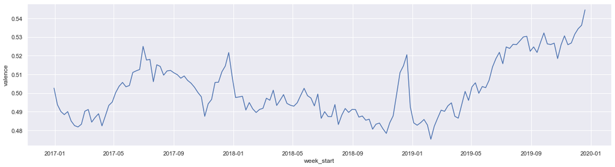

```python
sns.set_theme()
plt.figure(figsize=(20,5))
_ = sns.lineplot(x=weekly_valence.index, y=weekly_valence)
```

- Πόσο μεγάλη σημασία έχουν τα Χριστούγεννα!
- Και πόσο μελαγχολικός μήνας φαίνεται να είναι ο Φεβρουάριος...

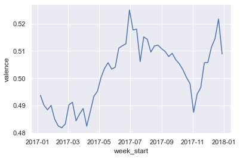

```python
weekly_valence_2017 = weekly_valence[weekly_valence.index.year == 2017]
_ = sns.lineplot(x=weekly_valence_2017.index, y=weekly_valence_2017)
```

- Το ίδιο βλέπουμε και την επόμενη χρονιά!

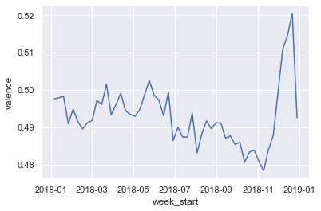

```python
weekly_valence_2018 = weekly_valence[weekly_valence.index.year == 2018]
_ = sns.lineplot(x=weekly_valence_2018.index, y=weekly_valence_2018)
```

- Αλλά δεν το βλέπουμε το 2019.
- Ο κόσμος φαίνεται να το γλεντούσε γενικώς, προφανώς δεν είχε συναίσθηση τι θα επερχόταν το 2020...

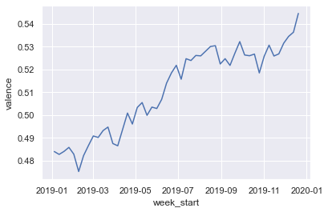

```python
weekly_valence_2019 = weekly_valence[weekly_valence.index.year == 2019]
_ = sns.lineplot(x=weekly_valence_2019.index, y=weekly_valence_2019)
```

- Γενικότερα πάντως, το σθένος των κομματιών φαίνεται να βρίσκεται προς το μέσο.

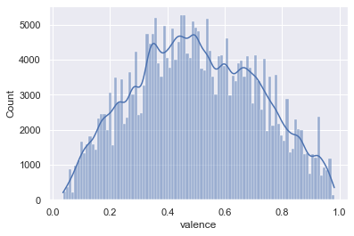

```python
sns.histplot(x='valence', data=all_charts, kde=True)
```

- Μπορούμε να δούμε την εικόνα σε μία συγκεκριμένη περιοχή, όπως στις ΗΠΑ:

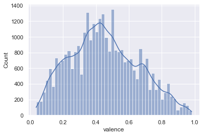

```python
sns.histplot(x='valence', data=all_charts[all_charts['region'] == 'us'], kde=True)
```

- Ή στη Βραζιλία:

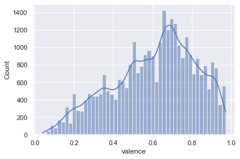

```python
sns.histplot(x='valence', data=all_charts[all_charts['region'] == 'br'], kde=True)
```

- Ή σε όλες τις περιοχές μαζί:

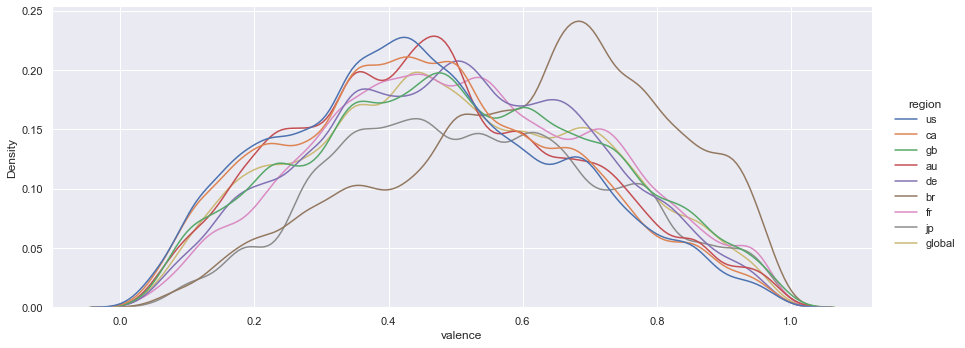

```python
plt.figure(figsize=(16, 10))
_ = sns.displot(x="valence", data=all_charts, hue="region", aspect=2.5, kind="kde")
```

- Ή στις ΗΠΑ, Βραζιλία, και σε όλον τον κόσμο:

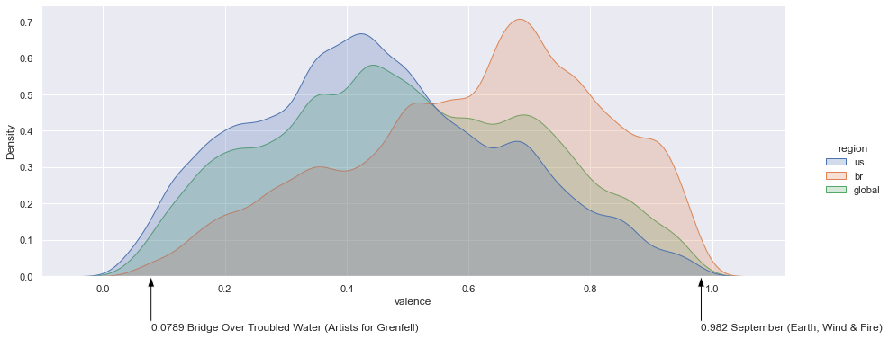

- Τα θηκογράμματα μπορούν να μας δείξουν το μέγεθος της διαφοράς ανά περιοχή:

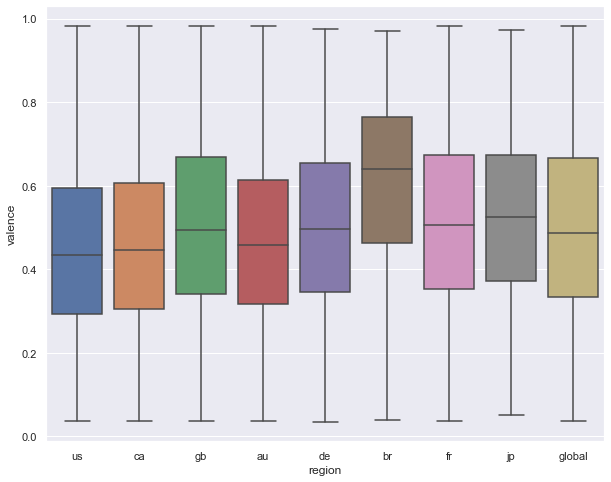

```python
plt.figure(figsize=(10, 8))
sns.boxplot(x='region', y='valence', data=all_charts)
```

- Μια ιδέα είναι να βάλουμε όλα τα ιστογράμματα σε ένα διάγραμμα, αλλά με έναν καλύτερο τρόπο.
- Θα ξεκινήσουμε παίρνοντας το μέσο σθένος σε αύξουσα σειρά.

```python
valence_by_region = all_charts[['region', 'valence']].groupby('region').mean().sort_values(by='valence')
valence_by_region.reset_index(inplace=True)
valence_by_region['region_valence_pos'] = valence_by_region.index
valence_by_region
```

|  | region | valence | region_valence_pos |
| --- | --- | --- | --- |
| 0 | us | 0.450253 | 0 |
| 1 | ca | 0.459242 | 1 |
| 2 | au | 0.469923 | 2 |
| 3 | global | 0.495207 | 3 |
| 4 | de | 0.499084 | 4 |
| 5 | gb | 0.501666 | 5 |
| 6 | fr | 0.510750 | 6 |
| 7 | jp | 0.529292 | 7 |
| 8 | br | 0.606860 | 8 |

- Θα προσθέσουμε τη θέση κάθε περιοχής, ως προς το σθένος, στο `DataFrame` `all_charts`.

```python
all_charts = pd.merge(all_charts, valence_by_region[['region', 'region_valence_pos']], on='region')
all_charts
```

|  | position | song_id | song_name | artist | streams | last_week_position | weeks_on_chart | peak_position | position_status | week_start | week_end | region | valence | region_valence_pos |
| --- | --- | --- | --- | --- | --- | --- | --- | --- | --- | --- | --- | --- | --- | --- |
| 0 | 1 | 7wGoVu4Dady5GV0Sv4UIsx | rockstar | Post Malone | 17532665 | 1.0 | 3 | 1 | 0 | 2017-10-20 | 2017-10-27 | us | 0.119 | 0 |
| 1 | 2 | 75ZvA4QfFiZvzhj2xkaWAh | I Fall Apart | Post Malone | 8350785 | 2.0 | 6 | 2 | 0 | 2017-10-20 | 2017-10-27 | us | 0.291 | 0 |
| 2 | 3 | 2fQrGHiQOvpL9UgPvtYy6G | Bank Account | 21 Savage | 7589124 | 4.0 | 5 | 3 | 1 | 2017-10-20 | 2017-10-27 | us | 0.376 | 0 |
| 3 | 4 | 43ZyHQITOjhciSUUNPVRHc | Gucci Gang | Lil Pump | 7584237 | 5.0 | 3 | 4 | 1 | 2017-10-20 | 2017-10-27 | us | 0.699 | 0 |
| 4 | 5 | 5tz69p7tJuGPeMGwNTxYuV | 1-800-273-8255 | Logic | 7527770 | 3.0 | 26 | 1 | -2 | 2017-10-20 | 2017-10-27 | us | 0.357 | 0 |
| ... | ... | ... | ... | ... | ... | ... | ... | ... | ... | ... | ... | ... | ... | ... |
| 273595 | 196 | 6kex4EBAj0WHXDKZMEJaaF | Swalla (feat. Nicki Minaj & Ty Dolla $ign) | Jason Derulo | 3747830 | 191.0 | 52 | 8 | -5 | 2018-03-02 | 2018-03-09 | global | 0.782 | 3 |
| 273596 | 197 | 0CokSRCu5hZgPxcZBaEzVE | Glorious (feat. Skylar Grey) | Macklemore | 3725286 | 189.0 | 24 | 14 | -8 | 2018-03-02 | 2018-03-09 | global | 0.356 | 3 |
| 273597 | 198 | 7oK9VyNzrYvRFo7nQEYkWN | Mr. Brightside | The Killers | 3717326 | 195.0 | 17 | 148 | -3 | 2018-03-02 | 2018-03-09 | global | 0.232 | 3 |
| 273598 | 199 | 7EUfNvyCVxQV3oN5ScA2Lb | Next To Me | Imagine Dragons | 3681739 | 122.0 | 2 | 122 | -77 | 2018-03-02 | 2018-03-09 | global | 0.351 | 3 |
| 273599 | 200 | 6u0EAxf1OJTLS7CvInuNd7 | Vai malandra (feat. Tropkillaz & DJ Yuri Martins) | Anitta | 3676542 | 177.0 | 12 | 30 | -23 | 2018-03-02 | 2018-03-09 | global | 0.557 | 3 |

273600 rows × 14 columns

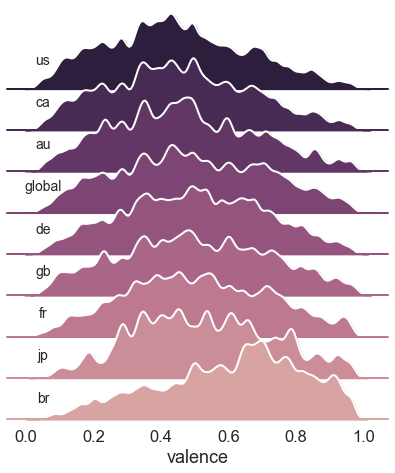

- Είναι φανερό ότι το σθένος διαφέρει από περιοχή σε περιοχή.
- Αλλά οι διαφορές αυτές είναι στατιστικά σημαντικές;
- Για να το διελευκάνουμε αυτό θα χρησιμοποιήσουμε την Ανάλυση Διακύμανσης (Analysis of Variance, ANOVA).
- Στην ANOVA ελέγχουμε τη διακύμανση εντός των ομάδων σε σχέση με τη διακύμανση μεταξύ των ομάδων των δεδομένων μας.
- Αν η διακύμανση μεταξύ των ομάδων είναι μεγάλη σε σχέση με τη διακύμανση εντός των ομάδων, τότε δεν είναι πιθανό οι διαφορές στις μέσες τιμές να είναι απλώς προϊόν τύχης.
- Για να χρησιμοιήσουμε ANOVA πρέπει να πληρούνται κάποιες συνθήκες.
- Μια συνθήκη είναι ότι τα δεδομένα σε κάθε ομάδα πρέπει να ακολουθούν την κανονική κατανομή.
- Για να το ελέγξουμε αυτό κατασκευάζουμε κατ΄ αρχήν ιστογράμματα για κάθε ομάδα, δηλαδή περιοχή.

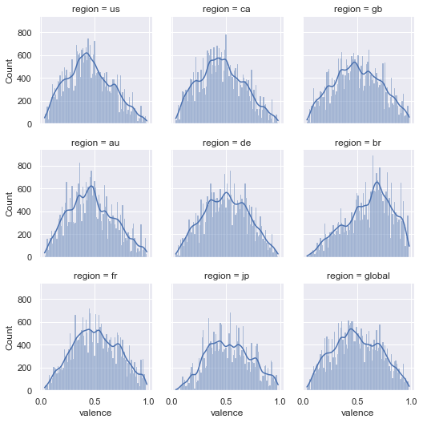

```python
sns.set_theme()
_ = sns.displot(all_charts, kde=True,
    x="valence", col="region", col_wrap=3, height=2.5, facet_kws=dict(margin_titles=True),
)
```

- Προχωράμε στην κατασκευή διαγραμμάτων QQ, ένα ανά περιοχή.

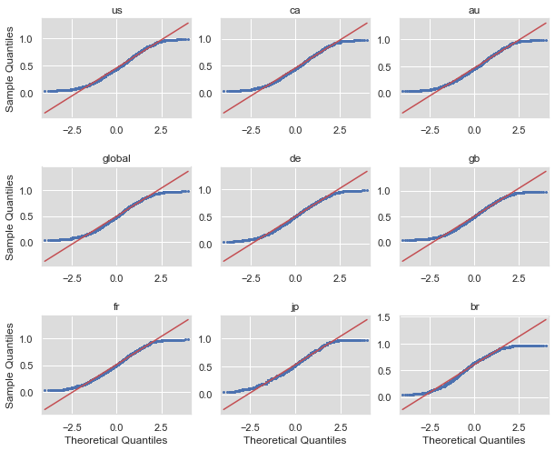

- Μία άλλη συνθήκη που πρέπει να πληρούν τα δεδομένα είναι οι ομάδες να έχουν την ίδια διακύμανση.
- Αυτό μπορούμε να το ελέγξουμε άμεσα.

```python
all_charts[['region', 'valence']].groupby('region').var()
```

| region | valence |
| --- | --- |
| au | 0.043604 |
| br | 0.044162 |
| ca | 0.043102 |
| de | 0.042368 |
| fr | 0.044110 |
| gb | 0.047708 |
| global | 0.046950 |
| jp | 0.041302 |
| us | 0.042434 |

- Έχοντας διαπιστώσει τα παραπάνω, προχωράμε στην ANOVA.
- Μπορούμε να χρησιμοποιήσουμε τη συνάρτηση `f_oneway()` της βιβλιοθήκης SciPy.
- Η συνάρτηση αυτή παίρνει σαν παραμέτρους τις ομάδες που θέλουμε να συγκρίνουμε.
- Θα πρέπει να διαχειριστούμε λίγο τα δεδομένα μας πρώτα ώστε να έχουμε έναν πίνακα-γραμμή για κάθε ομάδα.
- Ξεκινάμε βάζοντας το σθένος κάθε κομματιού σε μία ξεχωριστή στήλη ανά περιοχή.

```python
region_valence = all_charts.pivot_table(values='valence',
                                        index=all_charts.index,
                                        columns='region',
                                        aggfunc='first')
region_valence
```

| region | au | br | ca | de | fr | gb | global | jp | us |
| --- | --- | --- | --- | --- | --- | --- | --- | --- | --- |
| 0 | NaN | NaN | NaN | NaN | NaN | NaN | NaN | NaN | 0.119 |
| 1 | NaN | NaN | NaN | NaN | NaN | NaN | NaN | NaN | 0.291 |
| 2 | NaN | NaN | NaN | NaN | NaN | NaN | NaN | NaN | 0.376 |
| 3 | NaN | NaN | NaN | NaN | NaN | NaN | NaN | NaN | 0.699 |
| 4 | NaN | NaN | NaN | NaN | NaN | NaN | NaN | NaN | 0.357 |
| ... | ... | ... | ... | ... | ... | ... | ... | ... | ... |
| 273595 | NaN | NaN | NaN | NaN | NaN | NaN | 0.782 | NaN | NaN |
| 273596 | NaN | NaN | NaN | NaN | NaN | NaN | 0.356 | NaN | NaN |
| 273597 | NaN | NaN | NaN | NaN | NaN | NaN | 0.232 | NaN | NaN |
| 273598 | NaN | NaN | NaN | NaN | NaN | NaN | 0.351 | NaN | NaN |
| 273599 | NaN | NaN | NaN | NaN | NaN | NaN | 0.557 | NaN | NaN |

273600 rows × 9 columns

- Σπάμε το `DataFrame` στις επιμέρους στήλες ώστε να πάρουμε μονοδιάστατους πίνακες.

```python
region_valence_groups = np.split(region_valence.values, region_valence.shape[1], axis=1)
for rvc in region_valence_groups:
    print(rvc.shape)
```

```
(273600, 1)
(273600, 1)
(273600, 1)
(273600, 1)
(273600, 1)
(273600, 1)
(273600, 1)
(273600, 1)
(273600, 1)
```

- Ξέρουμε ότι υπάρχουν`NaN`, οπότε τα καθαρίζουμε.

```python
region_valence_groups = [ c[~np.isnan(c)] for c in region_valence_groups ]
for rvc in region_valence_groups:
    print(rvc.shape, rvc)
```

```
(31200,) [0.813 0.632 0.811 ... 0.789 0.193 0.404]
(31200,) [0.637 0.962 0.705 ... 0.583 0.506 0.781]
(31200,) [0.931 0.219 0.175 ... 0.419 0.689 0.111]
(31200,) [0.746 0.693 0.119 ... 0.62  0.344 0.552]
(31200,) [0.371 0.535 0.319 ... 0.28  0.333 0.558]
(31200,) [0.813 0.811 0.966 ... 0.268 0.51  0.863]
(30800,) [0.931 0.471 0.535 ... 0.232 0.351 0.557]
(24400,) [0.931 0.292 0.327 ... 0.571 0.894 0.41 ]
(31200,) [0.119 0.291 0.376 ... 0.357 0.274 0.447]
```

- Τώρα μπορούμε να δώσουμε τις ομάδες στη συνάρτηση `f_oneway()`.
- Βλέπουμε ότι η τιμή της μετρικής F είναι υψηλή, άρα οι διαφορές στις μέσες τιμές του σθένους είναι απίθανο να οφείλονται στην τύχη.

```python
stats.f_oneway(*region_valence_groups)
```

```
F_onewayResult(statistic=1527.2713324700505, pvalue=0.0)
```

- ANOVA μπορούμε να χρησιμοποιήσουμε και δημιουργώντας ένα γραμμικό μοντέλο με το statsmodels (όπως όταν κάνουμε παλινδρόμηση).
- Στην πραγματικότητα αυτό είναι πιο εύκολο από την `f_oneway()` καθώς δεν χρειάζεται να προσαρμόσουμε τα δεδομένα μας καθόλου.

```python
region_valence_mod = smf.ols('valence ~ C(region)', data=all_charts)
region_valence_res = region_valence_mod.fit()
```

- Από το γραμμικό μοντέλο μπορούμε να πάρουμε τον πίνακα ANOVA χρησιμοποιώντας τη συνάρτηση `anova_lm()`.
- Αυτή μας δίνει μια πιο πλήρη εικόνα των αποτελεσμάτων.

```python
anova_table = sm.stats.anova_lm(region_valence_res)
anova_table
```

|  | df | sum_sq | mean_sq | F | PR(>F) |
| --- | --- | --- | --- | --- | --- |
| C(region) | 8.0 | 538.003711 | 67.250464 | 1527.271332 | 0.0 |
| Residual | 273591.0 | 12047.054952 | 0.044033 | NaN | NaN |

- Πώς ερμηνεύεται ο πίνακας;
- Να θυμηθούμε ότι στην ANOVA θέλουμε να συγκρίνουμε τη διακύμανση εντός των ομάδων σε σχέση με τη διακύμανση μεταξύ των ομάδων.
- Για να εκτιμήσουμε τη διακύμανση μεταξύ των ομάδων, ξεκινάμε υπολογίζοντας το άθροισμα των τετραγώνων της διαφοράς του μέσου όρου κάθε ομάδας $i$ από τον γενικό μέσο όρο:

$$ (\bar{x_i} - \bar{x})^2 $$

- Στη συνέχεια πολλαπλασιάζουμε κάθε άθροισμα με το πλήθος των στοιχείων κάθε ομάδας:

$$ n_i(\bar{x_i} - \bar{x})^2 $$

- Κατόπιν προσθέτουμε τα αθροίσματα για όλες τις ομάδες μας, έστω $k$:

$$ \sum_{i=1}^{k} n_i(\bar{x_i} - \bar{x})^2 $$

- Αυτό εμφανίζεται στη στήλη `sum_sq` στην πρώτη γραμμή του πίνακα ANOVA και ονομάζεται *άθροισμα τετραγώνων μεταξύ ομάδων* (between groups sum of squares).

```python
anova_table
```

|  | df | sum_sq | mean_sq | F | PR(>F) |
| --- | --- | --- | --- | --- | --- |
| C(region) | 8.0 | 538.003711 | 67.250464 | 1527.271332 | 0.0 |
| Residual | 273591.0 | 12047.054952 | 0.044033 | NaN | NaN |

- Διαιρούμε το `sum_sq` που έχουμε βρει με τους αντίστοιχους *βαθμούς ελευθερίας*.
- Οι βαθμοί ελευθερίας μετρούν πόσες από τις οντότητες που χειριζόμαστε είναι ελεύθερες ή ανεξάρτητες μεταξύ τους.
- Εδώ εργαζόμαστε με τους μέσους όρους των ομάδων και το γενικό μέσο όρο.
- Αν έχουμε $k$ ομάδες και ξέρουμε τους μέσους όρους $k - 1$ oμάδων και το γενικό μέσο όρο, από αυτούς μπορούμε να βρούμε και τον άλλο μέσο όρο που δεν ξέρουμε.
- Άρα για $k$ ομάδες $k-1$ μέσοι όροι μπορούν να μεταβάλλονται ελεύθερα. Ο άλλος μέσος όρος προκύπτει από τους $k-1$ και το γενικό όσο όρο.
- Έτσι για $k$ ομάδες έχουμε $k - 1$ βαθμούς ελευθερίας.
- Αυτό εμφανίζεται τη στήλη `df` στην πρώτη γραμμή του πίνακα ANOVA.

```python
anova_table
```

|  | df | sum_sq | mean_sq | F | PR(>F) |
| --- | --- | --- | --- | --- | --- |
| C(region) | 8.0 | 538.003711 | 67.250464 | 1527.271332 | 0.0 |
| Residual | 273591.0 | 12047.054952 | 0.044033 | NaN | NaN |

- Διαιρούμε το `sum_sq` με το `df` στην πρώτη γραμμή, οπότε παίρνουμε το μέσο άθροισμα των τετραγώνων, `mean_sq`.
- To `mean_sq` στην πρώτη γραμμή είναι η εκτίμηση για τη διακύμανση μεταξύ των ομάδων.

```python
anova_table
```

|  | df | sum_sq | mean_sq | F | PR(>F) |
| --- | --- | --- | --- | --- | --- |
| C(region) | 8.0 | 538.003711 | 67.250464 | 1527.271332 | 0.0 |
| Residual | 273591.0 | 12047.054952 | 0.044033 | NaN | NaN |

- Προχωράμε στη διακύμανση εντός των ομάδων.
- Για να την εκτιμήσουμε, ξεκινάμε με τα τετράγωνα της διαφοράς κάθε παρατήρησης $j$ από κάθε ομάδα $i$, $x_{ij}$, από το μέσο όρο της ομάδας.

$$ (x_{ij} - \bar{x_i})^2 $$

- Στη συνέχεια προσθέτουμε τα τετράγωνα:

$$ \sum_{i=1}^{k}\sum_{j=1}^{n_i} (x_{ij} - \bar{x_i})^2 $$

- Αυτό εμφανίζεται στη στήλη `sum_sq` στη δεύτερη γραμμή του πίνακα ANOVA και ονομάζεται *άθροισμα τετραγώνων εντός των ομάδων* (inside groups sum of squares).

```python
anova_table
```

|  | df | sum_sq | mean_sq | F | PR(>F) |
| --- | --- | --- | --- | --- | --- |
| C(region) | 8.0 | 538.003711 | 67.250464 | 1527.271332 | 0.0 |
| Residual | 273591.0 | 12047.054952 | 0.044033 | NaN | NaN |

- Διαιρούμε το εντός των ομάδων `sum_sq` πάλι με τους αντίστοιχους βαθμούς ελευθερίας.
- Σε κάθε ομάδα, κάθε παρατήρηση μπορεί να προκύψει από τις υπόλοιπες παρατηρήσεις και το μέσο όρο, επομένως οι βαθμοί ελευθερίας κάθε ομάδας είναι $n_i - 1$.
- Άρα αν έχουμε $k$ ομάδες, οι βαθμοί ελευθερίας εντός των ομάδων είναι $n - k$, όπου $n$ είναι το συνολικό πλήθος των παρατηρήσεών μας.
- Αυτό εμφανίζεται τη στήλη `df` στη δεύτερη γραμμή του πίνακα ANOVA.

```python
anova_table
```

|  | df | sum_sq | mean_sq | F | PR(>F) |
| --- | --- | --- | --- | --- | --- |
| C(region) | 8.0 | 538.003711 | 67.250464 | 1527.271332 | 0.0 |
| Residual | 273591.0 | 12047.054952 | 0.044033 | NaN | NaN |

- Διαιρούμε το `sum_sq` με το `df` στη δεύτερη γραμμή, οπότε παίρνουμε το μέσο άθροισμα των τετραγώνων, `mean_sq`.
- To `mean_sq` στη δεύτερη γραμμή είναι η εκτίμηση για τη διακύμανση εντός των ομάδων.

```python
anova_table
```

|  | df | sum_sq | mean_sq | F | PR(>F) |
| --- | --- | --- | --- | --- | --- |
| C(region) | 8.0 | 538.003711 | 67.250464 | 1527.271332 | 0.0 |
| Residual | 273591.0 | 12047.054952 | 0.044033 | NaN | NaN |

- Η μετρική `F` στην τέταρτη στήλη είναι ο λόγος του `mean_sq` της πρώτης γραμμής με το `mean_sq` της δεύτερης γραμμής.

```python
anova_table
```

|  | df | sum_sq | mean_sq | F | PR(>F) |
| --- | --- | --- | --- | --- | --- |
| C(region) | 8.0 | 538.003711 | 67.250464 | 1527.271332 | 0.0 |
| Residual | 273591.0 | 12047.054952 | 0.044033 | NaN | NaN |